# TP_5

Emilie Groschêne

01 mai 2021

# Exercice

## Fusion des deux tables

Charger les données (les deux tables de l’enquete DM1), les fusionner. Garder seulement les patients qui sont en communs.

```r
enquete1 = read.table("../data/enqueteDM1.csv", header = TRUE, sep = ";", stringsAsFactors = FALSE)
enquete2 = read.table("../data/enqueteDM1p2.csv",sep=";",h=T)

enquete = merge(enquete1,enquete2,by.x ="idquest",by.y="QUEST",all=F)
```

## Correction des variables

Créer une nouvelle table avec des variables correctement définies (variables des questions 1 à 6)

- Création variable Sexe avec les valeurs Maculin / Féminin
- Création variable Enfants avec les valeurs OUI / NON
- Création variable Nb_Enfants au format numérique
- Création variable Mode_de_vie avec les valeurs de l’enquête: seul, en couple…
- Création de la variable Transmission avec les valeurs Père / Mère

```r
enquete <- mutate(enquete, Sexe = case_when(X1.sexe == 1 ~ "FEMININ",
                                            X1.sexe == 2 ~ "MASCULIN"))

enquete <- mutate(enquete, Enfants = case_when(X1.enfant == 1 ~ "OUI",
                                               X1.enfant == 2 ~ "NON"))

enquete <- mutate(enquete, Nb_Enfants = as.numeric(X1.nbenfant))
enquete <- mutate(enquete, Mode_de_vie = case_when(X3.modevie.1 == 1 ~ "SEUL",
                                                   X3.modevie.2 == 1 ~ "COUPLE",
                                                   X3.modevie.3 == 1 ~ "PARENTS",
                                                   X3.modevie.4 == 1 ~ "HAB IND INDEP",
                                                   X3.modevie.5 == 1 ~ "ETAB SOIN",
                                                   X3.modevie.6 == 1 ~ "FOYER HANDICAP"))


enquete <- mutate(enquete, Transmission = case_when(X5.1pere == 1 ~ "PERE",
                                                    X5.1mere == 2 ~ "MERE"))

paged_table(enquete[ ,c("idquest", "Sexe", "Enfants", "Nb_Enfants", "Mode_de_vie", "Transmission")])
```

| idquest | Sexe | Enfants | Nb_Enfants | Mode_de_vie | Transmission |
| --- | --- | --- | --- | --- | --- |
| 1 | MASCULIN | NA | 0 | PARENTS | PERE |
| 2 | FEMININ | OUI | 2 | COUPLE | PERE |
| 3 | FEMININ | OUI | 1 | COUPLE | NA |
| 4 | MASCULIN | NA | NA | SEUL | NA |
| 5 | MASCULIN | NA | NA | SEUL | PERE |
| 6 | FEMININ | OUI | 1 | PARENTS | PERE |
| 7 | MASCULIN | NA | NA | PARENTS | NA |
| 8 | FEMININ | NA | NA | COUPLE | PERE |
| 9 | FEMININ | OUI | 1 | HAB IND INDEP | NA |
| 10 | FEMININ | NA | NA | SEUL | NA |

[output cut: 790 more lines]

Calculer le délai de diagnostic ? et l’IMC ? Mettre l’IMC par classe.

```r
enquete <- mutate(enquete, Delai_diag = abs(X4.age.diagnostic - X4.age.debut))

enquete <- mutate(enquete, IMC = X1.poids / (X1.taille/100)^2)

enquete <- mutate(enquete, IMC_Class = case_when(IMC >= 30 & IMC <= 40 ~ "Obésité",
                                                       IMC >= 25 & IMC < 30 ~ "Surpoids",
                                                       IMC >= 18 & IMC < 25 ~ "Normal",
                                                       IMC < 18 ~ "Maigre"))

paged_table(enquete[ ,c("idquest", "Delai_diag", "IMC", "IMC_Class")])
```

| idquest | Delai_diag | IMC | IMC_Class |
| --- | --- | --- | --- |
| 1 | 2 | 20.01773 | Normal |
| 2 | 1 | 31.11111 | Obésité |
| 3 | 0 | 23.87511 | Normal |
| 4 | 16 | 24.21229 | Normal |
| 5 | 21 | 23.03005 | Normal |
| 6 | NA | 25.71166 | Surpoids |
| 7 | 8 | 19.13265 | Normal |
| 8 | NA | 32.90665 | Obésité |
| 9 | 5 | 32.45568 | Obésité |
| 10 | 6 | 25.76298 | Surpoids |

[output cut: 790 more lines]

Décrivez rapidement ces variables. Pouvez vous repérer des incohérences ?

```r
toModify1 <- enquete[which(enquete$X1.taille == 62), drop = F, c("X1.taille", "X1.age")] # drop pour voir le n° de ligne
toModify2 <- enquete[which(enquete$IMC > 40), drop = F, c("X1.poids","X1.taille", "IMC")]

paged_table(toModify1)
```

|  | X1.taille | X1.age |
| --- | --- | --- |
| 11 | 62 | 64 |

```r
paged_table(toModify2)
```

|  | X1.poids | X1.taille | IMC |
| --- | --- | --- | --- |
| 11 | 60 | 62 | 156.08741 |
| 72 | 104 | 160 | 40.62500 |
| 78 | 160 | 186 | 46.24812 |
| 87 | 149 | 160 | 58.20312 |
| 101 | 122 | 162 | 46.48682 |
| 115 | 109 | 159 | 43.11538 |
| 357 | 115 | 160 | 44.92187 |
| 449 | 103 | 155 | 42.87201 |
| 499 | 120 | 172 | 40.56247 |
| 562 | 100 | 153 | 42.71861 |

[output cut: 2 more lines]

**On repère une taille de 62 cm ce qui vient biaiser le calcul de l’IMC.**

## Représentations

Distribution de l’âge

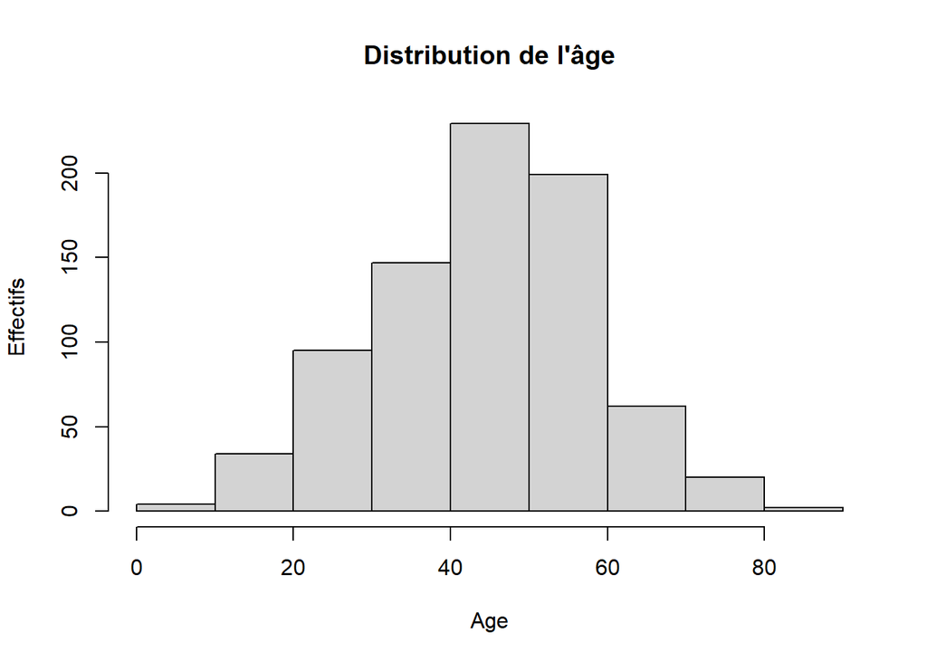

```r
hist(enquete$X1.age, ylab = "Effectifs", xlab = "Age", main = "Distribution de l'âge")
```

Distribution du sexe

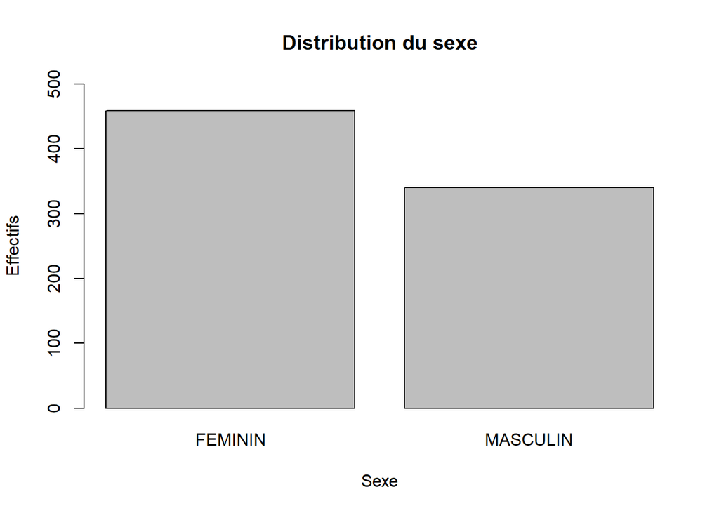

```r
table_sexe <- table(enquete$Sexe)
barplot(table_sexe, xlab = "Sexe", ylab = "Effectifs", main = "Distribution du sexe", ylim = c(0,500))
```

Distribution de l’âge selon le sexe

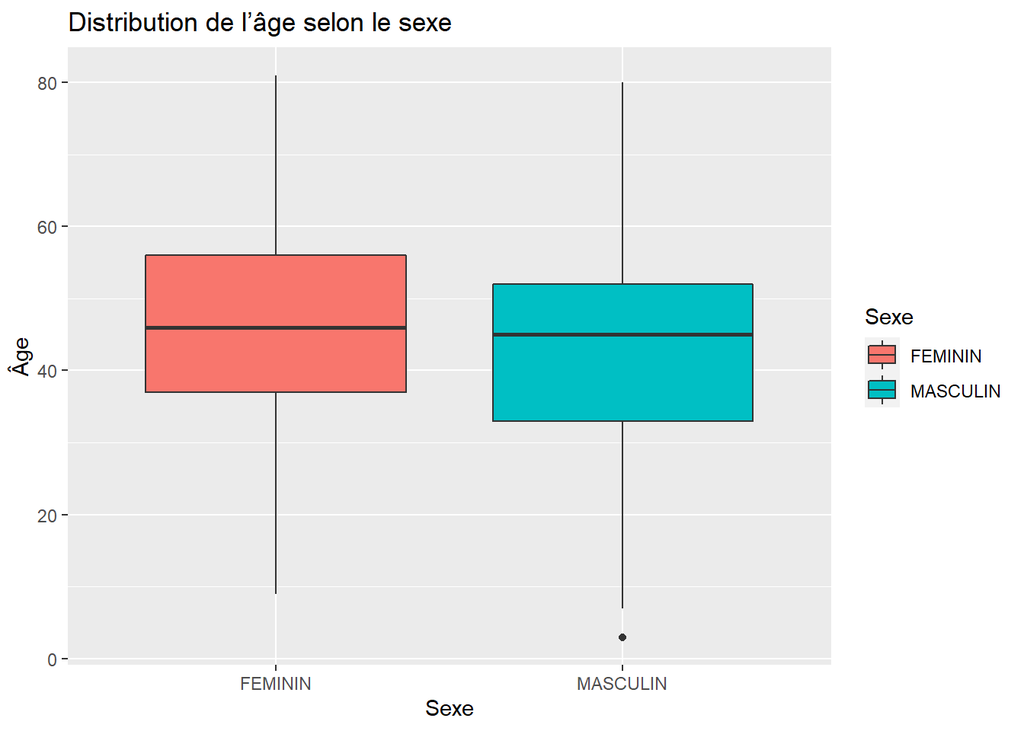

```r
qplot(Sexe, X1.age, data = subset(enquete, !is.na(X1.age) & !is.na(Sexe)), ylab= "Âge",
      main = "Distribution de l’âge selon le sexe", geom = "boxplot", fill = Sexe)
```

Distribution du poids en fonction de la taille

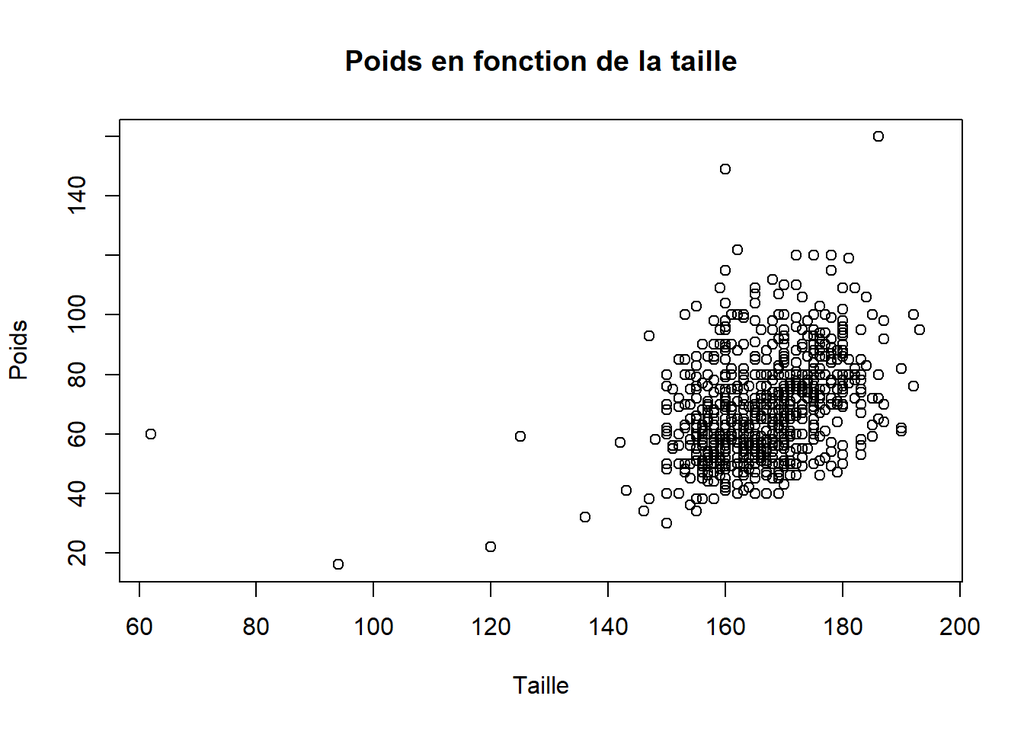

```r
plot(y = enquete$X1.poids, x = enquete$X1.taille, xlab = "Taille", ylab = "Poids",
     main = "Poids en fonction de la taille")
```

Distribution du mode de vie en classe selon le sexe.

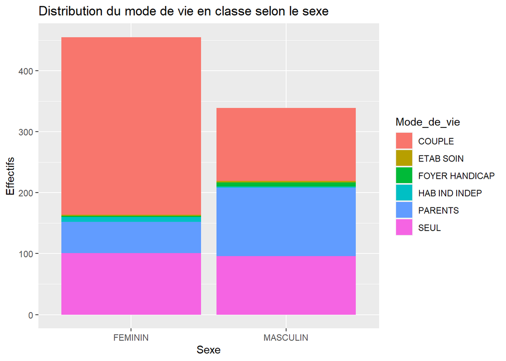

```r
qplot(data = subset(enquete, !is.na(Mode_de_vie) & !is.na(Sexe)), x = Sexe, fill = Mode_de_vie, geom = "bar",
      ylab = "Effectifs", main = "Distribution du mode de vie en classe selon le sexe")
```

## Apply

Calculer l’âge moyen des patients, la taille moyenne et le nombre total d’enfant avec apply.

```r
apply(select(enquete, X1.age, X1.taille), MARGIN = 2, FUN = mean, na.rm = TRUE) # âge et taille moyenne
```

```
##    X1.age X1.taille
##  44.75126 166.14559
```

```r
apply(select(enquete, Nb_Enfants), MARGIN = 2, FUN = sum, na.rm = TRUE) # nb total d'enfants
```

```
## Nb_Enfants
##        695
```

Calculer l’âge moyen et le nombre d’enfant total par sexe.

```r
tapply(enquete$X1.age, enquete$Sexe, FUN = mean, na.rm = TRUE) # âge moyen par sexe
```

```
##  FEMININ MASCULIN
## 45.94260 43.15976
```

```r
tapply(enquete$Nb_Enfants, enquete$Sexe, FUN = sum, na.rm = TRUE) # nb enfants par sexe
```

```
##  FEMININ MASCULIN
##      455      240
```

## Fonctions

```r
indic_quanti = function(x){
  res1 = min(x, na.rm = T)
  res2 = max(x, na.rm = T)
  res3 = median(x, na.rm = T)
  res4 = sd(x, na.rm = T)
  return(list(min = res1,max = res2,median = res3,sd = res4))
}

indic_quanti(enquete$IMC) # test sur la variable IMC
```

```
## $min
## [1] 13.33333
##
## $max
## [1] 156.0874
##
## $median
## [1] 24.15747
##
## $sd
## [1] 7.495663
```

Créer une fonction qui renvoie selon le type de la variable un descriptif.

```r
descriptif_var = function(x){
  if (is.numeric(x)){
    x = indic_quanti(x)
  }
  else if (is.character(x)){
    x = table(x)  #ou en prop.table aussi
  }
  else{
    x="C'est un logique"
  }
  return(x)
}

descriptif_var(enquete$Sexe) # test sur la varible qualitative sexe
```

```
## x
##  FEMININ MASCULIN
##      459      340
```

```r
descriptif_var(enquete$IMC) # test sur la varible quantitative IMC
```

```
## $min
## [1] 13.33333
##
## $max
## [1] 156.0874
##
## $median
## [1] 24.15747
##
## $sd
## [1] 7.495663
```

Appliquer cette dernière fonction avec la fonction sapply.

```r
sapply(enquete, descriptif_var, simplify = T)
```

**J’ai masqué le résultat car trop long (car je n’ai pas de sous dataframe avec uniquement les colonnes nécessaires)**

## Gestion des troubles

Calculer le nombre de troubles par type et par patient sans compter les troubles “autres” Créer autant de variables que de type de trouble.

```r
enquete <- mutate(enquete, Pb_musculaires = apply(select(enquete, X8.1.11, X8.1.12, X8.1.13),
                                                  MARGIN = 1, FUN = sum, na.rm = TRUE))

enquete <- mutate(enquete, Pb_ORL = apply(select(enquete, X8.1.21, X8.1.22, X8.1.23, X8.1.24, X8.1.25, X8.1.26),
                                                  MARGIN = 1, FUN = sum, na.rm = TRUE))

enquete <- mutate(enquete, Pb_yeux = apply(select(enquete, X8.1.31, X8.1.32, X8.1.33),
                                          MARGIN = 1, FUN = sum, na.rm = TRUE))

enquete <- mutate(enquete, Pb_digestifs = apply(select(enquete, X8.1.41, X8.1.42, X8.1.43, X8.1.44, X8.1.45, X8.1.46,X8.1.47, X8.1.48),
                                           MARGIN = 1, FUN = sum, na.rm = TRUE))

enquete <- mutate(enquete, Pb_cardio_resp = apply(select(enquete, X8.1.51, X8.1.52, X8.1.53, X8.1.54),
                                                MARGIN = 1, FUN = sum, na.rm = TRUE))

enquete <- mutate(enquete, Pb_psy = apply(select(enquete, X8.1.61, X8.1.62, X8.1.63, X8.1.64, X8.1.65, X8.1.66, X8.1.67),
                                                  MARGIN = 1, FUN = sum, na.rm = TRUE))

enquete <- mutate(enquete, Pb_bio = apply(select(enquete, X8.1.71, X8.1.72, X8.1.73, X8.1.74),
                                          MARGIN = 1, FUN = sum, na.rm = TRUE))

paged_table(enquete[ ,c(1,131, 132, 133, 134, 135, 136, 137)])
```

| idquest | Pb_musculaires | Pb_ORL | Pb_yeux | Pb_digestifs | Pb_cardio_resp | Pb_psy | Pb_bio |
| --- | --- | --- | --- | --- | --- | --- | --- |
| 1 | 2 | 2 | 1 | 1 | 2 | 3 | 0 |
| 2 | 2 | 0 | 0 | 1 | 1 | 0 | 0 |
| 3 | 0 | 0 | 0 | 0 | 0 | 0 | 0 |
| 4 | 3 | 2 | 0 | 5 | 3 | 1 | 0 |
| 5 | 2 | 2 | 1 | 3 | 2 | 2 | 1 |
| 6 | 3 | 2 | 1 | 2 | 1 | 4 | 0 |
| 7 | 2 | 2 | 0 | 1 | 0 | 3 | 0 |
| 8 | 2 | 2 | 1 | 3 | 2 | 1 | 2 |
| 9 | 2 | 2 | 1 | 0 | 1 | 0 | 1 |
| 10 | 3 | 2 | 0 | 3 | 1 | 1 | 0 |

[output cut: 790 more lines]

Représenter graphiquement la distribution du nombre de trouble types de troubles :

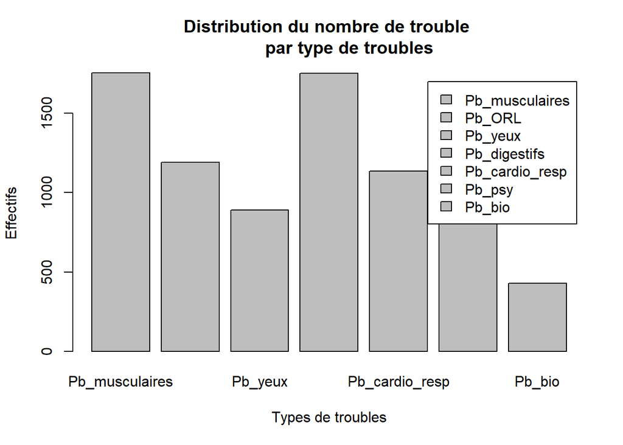

```r
table_types <- apply(select(enquete, Pb_musculaires, Pb_ORL, Pb_yeux, Pb_digestifs, Pb_cardio_resp, Pb_psy, Pb_bio), MARGIN = 2,
                     FUN = sum, na.rm = TRUE)

barplot(table_types, xlab = "Types de troubles", ylab = "Effectifs", main = "Distribution du nombre de trouble
        par type de troubles", legend = T)
```

**Comment faire le QPLOT pour améliorer ce graph? Illisible et pas terrible**

Représenter graphiquement le nombre de patient ayant chacun de ces troubles

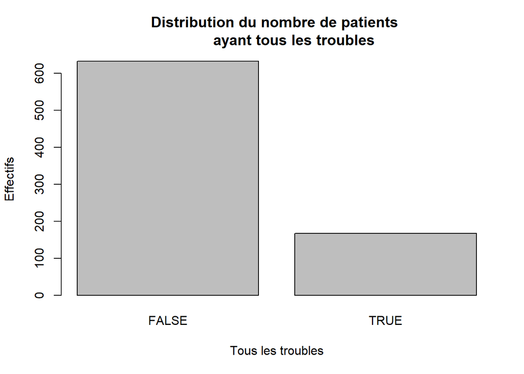

```r
enquete <- mutate(enquete, Tous_troubles = case_when(Pb_musculaires & Pb_ORL & Pb_yeux &
                                                     Pb_digestifs & Pb_cardio_resp & Pb_psy & Pb_bio != 0 ~ TRUE,
                                                     Pb_musculaires | Pb_ORL | Pb_yeux | Pb_digestifs |
                                                     Pb_cardio_resp | Pb_psy | Pb_bio == 0 ~ FALSE))

table_tousTroubles <- table(enquete$Tous_trouble)

barplot(table_tousTroubles, xlab = "Tous les troubles", ylab = "Effectifs", main = "Distribution du nombre de patients
        ayant tous les troubles", legend = F)
```

**Je ne suis pas sûre d’avoir bien répondu à la question**

Quel est le premier problème le plus génant ?

```r
first_pb <- count(enquete, X8.2.1, sort = TRUE)
first_pb[1, c(1,2)]
```

```
##   X8.2.1   n
## 1     12 234
```

**Le 12ème pb (faiblesse musculaire) a été signalé en premier comme le plus gênant par 234 personnes**

Créer un score pour connaître les troubles les plus génants.

- Le score vaut 3 si le problème est classé comme “premier problème”
- Le score vaut 2 si le problème est classé comme “deuxième problème”
- Le score vaut 1 si le problème est classé comme “troisième problème”

```r
first_pb <- count(enquete, X8.2.1, sort = TRUE) # j'indique pour chaque trouble du premier pb le nombre de fois où il est signalé
first_pb <- mutate(first_pb, score = 3) # je rajoute une variable score avec 3 en face de chaque n° de trouble

second_pb <- count(enquete, X8.2.2, sort = TRUE)
second_pb <- mutate(second_pb, score = 2)

third_pb <- count(enquete, X8.2.3, sort = TRUE)
third_pb <- mutate(third_pb, score = 1)
```

**Merge en deux temps car impossible de fusionner 3 dataframes d’un coup.**

**Cbind plutôt??**

```r
scoring <- merge(x = first_pb, y = second_pb, by.x = "X8.2.1", by.y = "X8.2.2", all = TRUE)
scoring1 <- merge(x = scoring, y = third_pb, by.x = "X8.2.1", by.y = "X8.2.3", all = TRUE)
```

**Je renomme les variables:**

```r
scoring1 <- rename(scoring1, Troubles = X8.2.1, Nb_Premier_pb = n.x, Score_Premier_pb = score.x, Nb_Deuxieme_pb = n.y,
       Score_Deuxième_pb = score.y, Nb_Troisième_pb = n, Score_Troisième_pb = score)

paged_table(scoring1)
```

| Troubles | Nb_Premier_pb | Score_Premier_pb | Nb_Deuxieme_pb | Score_Deuxième_pb | Nb_Troisième_pb | Score_Troisième_pb |
| --- | --- | --- | --- | --- | --- | --- |
| 10 | NA | NA | NA | NA | 1 | 1 |
| 11 | 96 | 3 | 27 | 2 | 24 | 1 |
| 12 | 234 | 3 | 79 | 2 | 42 | 1 |
| 13 | 63 | 3 | 46 | 2 | 34 | 1 |
| 14 | 13 | 3 | 7 | 2 | 6 | 1 |
| 16 | NA | NA | 1 | 2 | NA | NA |
| 20 | NA | NA | 1 | 2 | NA | NA |
| 21 | 10 | 3 | 8 | 2 | 8 | 1 |
| 22 | 1 | 3 | 5 | 2 | 2 | 1 |
| 23 | 1 | 3 | 1 | 2 | 1 | 1 |

[output cut: 45 more lines]

**Je créé une colonne qui multiplie pour chaque pb son nombre par son score**

**Comment faire un order() décroissant sur le score total?**

```r
scoring2 <- na.omit(scoring1) # j'enlève les NA du dataframe car je ne peux pas multiplier par NA.
scoring2 <- mutate(scoring2, Score_total_troubles = (Nb_Premier_pb * Score_Premier_pb + Nb_Deuxieme_pb * Score_Deuxième_pb +
                                                       Nb_Troisième_pb * Score_Troisième_pb))

paged_table(scoring2[ ,c("Troubles", "Score_total_troubles")])
```

|  | Troubles | Score_total_troubles |
| --- | --- | --- |
| 2 | 11 | 366 |
| 3 | 12 | 902 |
| 4 | 13 | 315 |
| 5 | 14 | 59 |
| 8 | 21 | 54 |
| 9 | 22 | 15 |
| 10 | 23 | 6 |
| 11 | 24 | 166 |
| 12 | 25 | 56 |
| 13 | 27 | 18 |

[output cut: 36 more lines]

Quels sont les relations causales entre 10.5 et 8.1. Représenter les distribution conjointes.

**Je calcule la somme de chaques difficultés** **Je me suis arrêtée là car je ne comprends pas pourquoi il y a des valeurs différentes de 0 ou 1 dans chaque variable (X10.5.1 à X10.5.28)** **Par exemple un patient ayant du mal à marcher à l’extérieur va cocher la case ou non. Je devrais donc avoir les valeurs 0 ou 1??**

```r
tapply(enquete$X10.5.1, enquete$X10.5.1, FUN = sum, na.rm = TRUE)
```

```
##   1   2   3   4   5   6   7   8   9  10  11  12  13  14  15  17  20  24  28
## 575  22 135 156 110  42  49  80 144 220  33  48  52  28 150  68  20  24  56
```

```r
class(tapply(enquete$X10.5.1, enquete$X10.5.1, FUN = sum, na.rm = TRUE))
```

```
## [1] "array"
```